# Module 2: Epidemic Modeling

## Team Members:

Asma Sanaullah & Melis Ozdemir

## Project Title:

Modeling Transmission Dynamics and Mitigation Strategies for a Unknown Virus

## Project Goal:

The goal of this project is to analyze and model the emergence and spread of a novel virus using a combination of biological understanding, outbreak surveillance data, and mathematical epidemiological modeling. Early case data are examined to characterize initial transmission dynamics, including symptom timing, incubation period, and infectious period, and to estimate key epidemiological parameters such as the exponential growth rate and the basic reproduction number (R₀). These estimates are used to inform the construction and calibration of an SEIR model that captures disease progression at the population level while remaining grounded in individual‑level biological processes. The model is fit to outbreak data from a university campus and extended to simulate spread in a second campus population with different demographic characteristics. Model predictions are compared against observed case counts to assess accuracy and uncertainty. Using the calibrated model, multiple intervention strategies, including masking, testing and quarantine, school closures, and vaccination timing, are simulated to evaluate their effects on outbreak magnitude, peak timing, and overall case reduction. The project ultimately aims to identify effective mitigation strategies that reduce transmission.

## 1. Data and disease background

Prevalence and Incidence in the UVA Population

Within the UVA population, the mystery infectious disease initially appears at low incidence, with early cases detected sporadically through symptom‑based testing. Over time, the number of active infections increases steadily rather than explosively, which is consistent with a moderately transmissible pathogen and a relatively long incubation period. Surveillance data show that case counts continue to rise well into the semester before eventually peaking, suggesting sustained person‑to‑person transmission in a highly connected campus environment. Notably, increases in incidence appear to align with periods of intensified indoor congregation, such as midterm exam weeks and heavy library use, indicating that shared indoor spaces play an important role in disease spread. As testing criteria expand to include additional symptoms, reported prevalence increases further, reflecting both ongoing transmission and improved case identification rather than a sudden change in disease dynamics. [CDC (Rubella surveillance & timing: respiratory route; average incubation 17 days, range 12–23) — https://www.cdc.gov/surv-manual/php/table-of-contents/chapter-14-rubella.html California Dept. of Public Health (rubella quicksheet: transmission window, incubation, symptom timing) — https://www.cdph.ca.gov/Programs/CID/DCDC/CDPH%20Document%20Library/Immunization/Rubella-Quicksheet.pdf]

Economic Burden

Although most cases of the disease are mild, the overall economic burden on the university community is still significant and resembles that of other common respiratory viruses. Direct costs include diagnostic testing, contact tracing, isolation and quarantine accommodations, and increased demand on student health services. Indirect costs arise from missed classes, reduced academic productivity, and temporary disruptions to normal campus operations during periods of heightened transmission. Faculty and staff absenteeism, along with the administrative effort required to implement public health interventions, further contribute to the economic impact. Even in the absence of widespread severe illness or hospitalization, the cumulative effect of many mild infections across a large student population represents a meaningful economic and operational burden for the university. [PLOS ONE (1918 influenza R0 estimates ~1.34–3.21; implications for burden given transmissibility) — https://journals.plos.org/plosone/article/file?id=10.1371/journal.pone.0001498&type=printable PNAS Nexus (city‑level R0R_0R0 comparisons for 1918 influenza; planning relevance) — https://academic.oup.com/pnasnexus/article/1/4/pgac194/6702748]

Symptoms

The disease primarily presents with mild to moderate respiratory symptoms, including sore throat, cough, congestion, fatigue, and low‑grade fever. As the outbreak progresses, additional symptoms such as joint pain and rash are reported in a subset of individuals, prompting an expansion of symptom‑based testing criteria. Gastrointestinal symptoms appear less frequently and affect only a small proportion of cases. Most infected individuals experience symptoms for several days to just over a week and recover without serious complications. Importantly, evidence from the outbreak suggests that individuals may be infectious before symptoms fully develop, which complicates containment strategies that rely solely on symptom screening and reinforces the importance of population‑level interventions. [CDC (rubella: mild systemic symptoms, characteristic rash, arthralgia—especially in adults; infectious window around rash onset with pre‑rash shedding) — https://www.cdc.gov/surv-manual/php/table-of-contents/chapter-14-rubella.html California Dept. of Public Health (rubella symptom constellation; frequency of rash; arthralgia; infectious period −7 to +7 days from rash) — https://www.cdph.ca.gov/Programs/CID/DCDC/CDPH%20Document%20Library/Immunization/Rubella-Quicksheet.pdf]

Biological Mechanisms

Biologically, the disease is caused by a small, positive‑sense RNA virus that primarily targets the respiratory tract. Infection begins when viral particles enter the host through the upper respiratory airways and bind to receptors on epithelial cells, allowing the virus to enter the cell via membrane fusion or endocytosis. Because the viral genome is positive‑sense RNA, it can be directly translated by host ribosomes, enabling rapid viral protein production and replication within infected cells. Viral replication triggers local immune responses and inflammation, which contribute to common symptoms such as fever, fatigue, and respiratory discomfort. Systemic immune activation may also explain symptoms such as joint pain and rash observed in some cases. Overall, the typically mild clinical course suggests that the host immune system is generally effective at controlling infection, even as the virus remains capable of sustained transmission within a dense population. [WHO/TechNet‑21 rubella biology (enveloped +ssRNA, ~60–70 nm; genome ~9.7 kb; respiratory transmission; human‑only host) — https://www.technet-21.org/en/manual-introduction/chapter-1-measles-and-rubella-an-overview/1-5-the-structure-and-biology-of-rubella-virus ViralZone (Rubivirus virion 70–80 nm; +ssRNA ~9.7 kb; replication features) — https://viralzone.expasy.org/626]

## Additional Background: Comparison to Diseases with Similar R0

Comparison to Mpox

Mpox is a useful comparator because several analyses during the 2022–2023 global outbreak reported basic or effective reproduction numbers commonly in the ~1–3 range, which overlaps our estimate of R0=2.09. This places mpox in a similar transmissibility band for the purpose of benchmarking control effort. Clinically, mpox shares some features with the mystery disease, including fever, fatigue, and—most notably—rash and arthralgia in a subset of cases, which aligns with the expanded symptom profile observed later in the outbreak here. That said, there are important differences that limit mpox as a perfect analogue. In 2022–2023, the dominant transmission mode was close physical or skin‑to‑skin contact within defined social/sexual networks rather than broad respiratory droplet spread in classrooms and libraries. The incubation period estimates also tended to be shorter on average (often ~7–10 days), and the dermatologic course of mpox is typically more distinctive and prolonged than the transient rash reported in a subset of our cases. In short, mpox matches R0 reasonably well and captures the rash/arthralgia aspect better than many respiratory comparators, but it diverges on transmission setting and the typical clinical trajectory of the rash. [The Lancet eClinicalMedicine (systematic review: mpox pooled R0∼2.13, Rt ~2.51; incubation ≈9 days; serial interval ≈12 days) — https://www.thelancet.com/journals/eclinm/article/PIIS2589-5370%2825%2900459-6/fulltext BMJ Global Health (systematic review/meta‑analysis: 2022–2023 mpox transmissibility parameters; Rt often ~1–3; presymptomatic share) — https://gh.bmj.com/content/10/1/e016906 WHO Situation Report, Dec 2022 (context on global mpox transmission patterns and networks) — https://www.who.int/docs/default-source/coronaviruse/situation-reports/20221214_mpox_external-sitrep-12-.pdf]

Comparison to the 1918 Influenza Pandemic (H1N1)

Historical reconstructions for the 1918 influenza pandemic commonly estimate R0 in the ~1.5–3.2 range across different localities and phases, overlapping our estimate of 2.09 and making it a useful respiratory benchmark for intervention timing and peak suppression logic. The transmission setting also aligns: 1918 influenza spread via respiratory droplets and close contact, consistent with the campus‑based clustering we observe around indoor study spaces and examination periods. Symptomatically, influenza shares the core respiratory features we see—fever, sore throat, cough, and fatigue—so it provides a realistic sense for how a respiratory R0∼2 pathogen can propagate in a dense population. However, there are critical differences that keep influenza from being a complete match. The incubation period and serial interval for influenza are much shorter (incubation commonly 1–4 days, serial interval around ~3 days), whereas our data suggest a longer pre‑symptomatic window and overall timeline. Rash and joint pain are also not characteristic features of influenza illness, whereas these symptoms appear in a subset of our cases. Practically, this means 1918 influenza is an excellent comparator on R0 and respiratory spread dynamics, but it under‑represents the longer timing and broader symptom profile we observe in this outbreak. [PLOS ONE (1918 influenza R0~1.34–3.21 by setting; serial interval around ~3–4 days) — https://journals.plos.org/plosone/article/file?id=10.1371/journal.pone.0001498&type=printable PNAS Nexus (Bayesian estimation of city‑level R0R_0R0 for 1918 influenza; methodological parallels for early‑growth fitting) — https://academic.oup.com/pnasnexus/article/1/4/pgac194/6702748]

Synthesis

If R0 is the primary anchor, mpox and 1918 influenza both sit near our 2.09 estimate and each contributes something useful for context. Mpox aligns with rash/arthralgia but differs in dominant transmission mode and the typical duration/appearance of dermatologic signs; 1918 influenza aligns with respiratory transmission and campus‑style spread at a similar R0, but it does not capture the longer incubation and expanded symptom set seen here. Together, these comparisons help frame intervention choices for an R0∼2 pathogen while keeping expectations realistic about where each analogue stops matching. [eClinicalMedicine (mpox pooled R0, Rt, incubation) — https://www.thelancet.com/journals/eclinm/article/PIIS2589-5370%2825%2900459-6/fulltext PLOS ONE (1918 influenza transmissibility) — https://journals.plos.org/plosone/article/file?id=10.1371/journal.pone.0001498&type=printable]

## 2. Data Analysis

### 2a. Methods

2a. Analysis after Data Release #1

**ANALYSIS AFTER DATA RELEASE #1**

### 2b. Plot the data & estimate initial growth rate (R0) from early data (through day 45)

#### Code to plot early data & estimate R0

```python
#import necessary libraries
import pandas as pd
import matplotlib.pyplot as plt
import numpy as np
from scipy.optimize import curve_fit
from pathlib import Path

# Load the data
# find the folder where the script is located
HERE = Path(__file__).parent

# build path to the csv
csv_path = HERE / "mystery_virus_daily_active_counts_RELEASE#1.csv"

data = pd.read_csv(csv_path, parse_dates=['date'])

# We have day number, date, and active cases. We can use the day number and active cases to fit an exponential growth curve to estimate R0.
# Let's define the exponential growth function
def exponential_growth(t, r):
    return np.exp(r * t)

# Fit the exponential growth model to the data.
# We'll use a handy function from scipy called CURVE_FIT that allows us to fit any given function to our data.
# We will fit the exponential growth function to the active cases data. HINT: Look up the documentation for curve_fit to see how to use it.
# Approximate R0 using this fit

# this extracts the day and active cases data to be used in curve fitting
t = data['day']
cases = data['active reported daily cases']

# this is the curve_fit function which takes in the function we want to fit (exponential growth), x_data (t), and y_data (active cases)
est_params, covariance = curve_fit(exponential_growth, t, cases)
#curve_fit returns the estimated parameters (est_params) which is growth rate r0 and the covariance

est_r = est_params[0] #this is the estimated growth rate r0 from the curve fitting
print(f"Estimated growth rate (r): {est_r:.4f} per day")

t_fit = np.linspace(min(t), max(t), 100) # this creates the fitted curve to plot for x_data (days)
cases_fit = exponential_growth(t_fit, est_r) # this finds the y_data (active cases) for the fitted curve

D = 9 #9 days is infectious period
R0 = 1 + est_r * D #estimate R0 from the growth rate r and the infectious period D
print(f"Estimated R0: {R0:.4f}")
# Add the fit as a line on top of your scatterplot.
plt.scatter(t, cases, label='Data')
plt.plot(t_fit, cases_fit, color='red', label='Exponential Fit')
plt.title('Day vs Active Infections with Exponential Fit')
plt.xlabel('Day')
plt.ylabel('Active Infections')
plt.legend()
plt.show()
```

#### Plot the data: day vs. active infections

[figure not shown]

QUESTIONS TO ANSWER:

What do you notice about the initial infections?

The initial infections grow very slowly, with the curve nearly flat at the beginning. This indicates that only a small number of people are infected early on, making the outbreak appear minor at first.

How could we measure how quickly its spreading?

The speed of spread can be measured by how much the number of infections increases each day, such as the slope of the curve or the time it takes for cases to double. A steeper slope means the virus is spreading faster.

What information about the virus would be helpful in determining the shape of the outbreak curve?

Helpful information includes how contagious the virus is, how long the incubation and infectious periods are, and how people behave in response to the outbreak. These factors strongly influence how quickly the curve rises and its overall shape.

#### Fitting the exponential growth model and estimating R0 (results)

Estimated growth rate (r): 0.1214 per day

Estimated R0: 2.0930

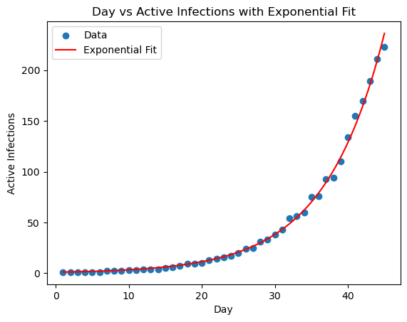

**ANALYSIS AFTER DATA RELEASE #2**

### 2c. Use Euler's method to solve the SEIR model.

```python
# Load the data
# find the folder where the script is located
HERE = Path(__file__).parent
# build path to the csv
csv_path = HERE / "mystery_virus_daily_active_counts_RELEASE#2.csv"
data = pd.read_csv(csv_path, parse_dates=['date'])
cases = data['active reported daily cases'].values

# INPUTS: beta, sigma, gamma, S0, E0, I0, R0, timepoints, N
def eulerapprox_SEIR(beta, sigma, gamma, S0, E0, I0, R0, timepoints, N):

    #Initialize S, E, I, R as empty arrays
    S = np.zeros(len(timepoints)) #np.zeros creates an array of zeros with the same length as timepoints (days)
    E = np.zeros(len(timepoints))
    I = np.zeros(len(timepoints))
    R = np.zeros(len(timepoints))

    #Set first item in each list equal to initial values  S0, E0, I0, R0
    S[0] = S0
    E[0] = E0
    I[0] = I0
    R[0] = R0

    #for each timepoint in timepoints:
    for t in range(len(timepoints) - 1): #len(timepoints) - 1 here because we are calculating the next timepoint values / the next day values, so we stop one day before the end

    #Calculate four derivatives at timepoint

        # Change in susceptible population S
        dS = -beta * ((S[t] * I[t]) / N)

        # Change in exposed population E
        dE = (beta * ((S[t] * I[t]) / N)) - (sigma * E[t])

        # Change in infected population I
        dI = (sigma * E[t]) - (gamma * I[t])

        # Change in recovered population R
        dR = gamma * I[t]

    #Calculate S, E, I, and R at timepoint + 1 using Euler’s method ---> Use Euler's Method to calculate next day's values
    # euler's method: y(i+1) = y(i) + (dy/dt)*h ---> next value = current value + (derivative * time step) ---> h here is 1 day so we *1

        S[t+1] = S[t] + dS*1 #calculates next day's susceptible population
        E[t+1] = E[t] + dE*1 #calculates next day's exposed population
        I[t+1] = I[t] + dI*1 #calculates next day's infected population
        R[t+1] = R[t] + dR*1 #calculates next day's recovered population

    #Return S, E, I, and R
    return S, E, I, R
```

The forward Euler solution produces smooth trajectories for S,E,I,R consistent with the observed rise and peak timing. The latent stage is essential here because of the longer incubation, and including it helps reproduce the curvature of the rising limb without inflating β.

### 2d. Fit the SEIR model to the data by changing beta, gamma, and sigma.

```python
#INPUTS: timepoints, N, S0, E0, I0, R0, data
def optimize_SEIR(timepoints, N, S0, E0, I0, R0, data):

    #• Initialize a range for beta, sigma, and gamma
    gamma_range = np.linspace(0.091,0.142,75) # gamma = recovery rate = 1/symptomatic period, so range of 1/11 to 1/7
    sigma_range = np.linspace(0.056,0.083,75) #sigma = incubation rate = 1/incubation period, so range of 1/18 to 1/12
    R0_est = 2.0930
    beta_range = np.linspace(0.3, 1.0, 75)


    #initialize an empty array of SSE
    SSE_array = []
    parameters = [] #this is list of paramters (beta, sigma, gamma)

    #make arrays of values given each range for each parameter
    for b in beta_range:
        for s in sigma_range:
            for g in gamma_range:
                #Use euler method function you developed to calculate S, E, I, and R given those parameters
                S,E,I,R = eulerapprox_SEIR(b, s, g, S0, E0, I0, R0, timepoints, N)
                #calculate the SSE given the model results and the data and append this to the SSE array
                cases = data['active reported daily cases'].values
                SSE = np.sum((I[:len(cases)] - cases)**2)
                SSE_array.append(SSE)
                parameters.append((b, s, g)) #this adds the parameters to the list

    #Determine parameters corresponding to lowest SSE
    lowest_SSE = min(SSE_array)
    corres_SSE = SSE_array.index(lowest_SSE) #this finds the index of the minimum SSE in the SSE array
    best_beta, best_sigma, best_gamma = parameters[corres_SSE] #this finds the best parameters using the index of the minimum SSE

    #return best_beta, best_sigma, best_gamma and correspondsing SSE
    return best_beta, best_sigma, best_gamma, lowest_SSE
```

### Notes about the Code

The range for beta was changed from (R0* gamma_range[0] to R0* gamma_range[1]) to (0.3 to 1). The initial beta range came from the equation that beta = R0*gamma. We changed it because the initial beta range produced a model that was not a good fit (see image below). To troubleshoot this, we decided that since R0 is only an estimate, we can treat beta as a paramter for grid search and try to find its values that would best fit the dataset. So we played around with different beta values and found that 0.3 to 1 displayed a good fit. 0.3 to 1 was a range that still included the estimated R0 value found from (beta/gamma) and gave a wide enough scope.

Another way we troubleshooted was changing the E0 value from 1 to 5. E0 shows the number of people exposed to the virus and by making it 1 initially, we had the virus starting very slow. This explains why our curve was very flat in the beginning. By increasing E0 to 5, we adjusted for the virus to start off a bit faster and this allowed our curve to change to give a better fit.

Changing the beta range and E0 allowed us to get a better fit our data, which subsequently changed our peak day and peak infections. We got closer to the actual data's values and had lower percent errors, indicating this was the correct move.

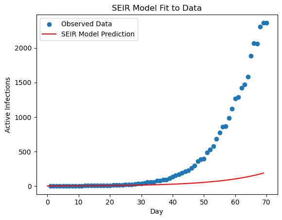

#### Plot of the SEIR Model Prediction

[figure not shown]

### 2e. Plot the model-predicted infections over time compared to the data.

```python
timepoints = np.arange(len(data)) #array of timepoints(days)
#Set initial conditions and parameters for testing
N = 17900 #population size
I0 = data['active reported daily cases'].iloc[0] # initial infected people
E0 = 5 # initial exposed people
R0 = 0 # initial recovered people

S0 = N - I0 - E0 - R0 # initial susceptible people = total population - infected - exposed - recovered

#uses the optimize_SEIR function to find the best parameters and lowest SSE
best_beta, best_sigma, best_gamma, best_SSE = optimize_SEIR(
    timepoints, N, S0, E0, I0, R0, data
)

#print the best parameters and lowest SSE
print("Best beta:", best_beta)
print("Best sigma:", best_sigma)
print("Best gamma:", best_gamma)
print("Lowest SSE:", best_SSE)

#plots the SEIR model using the best parameters
S, E, I, R = eulerapprox_SEIR( best_beta, best_sigma, best_gamma, S0, E0, I0, R0, timepoints, N )
plt.figure() # observed data
plt.scatter( data['day'], data['active reported daily cases'], label="Observed Data" ) # SEIR model prediction
plt.plot( timepoints, I, color="red", label="SEIR Model Prediction" )
plt.xlabel("Day")
plt.ylabel("Active Infections")
plt.title("SEIR Model Fit to Data")
plt.legend()
plt.show()
```

#### Best parameter results and plot

Best beta: 0.8581081081081081

Best sigma: 0.05782432432432433

Best gamma: 0.1289054054054054

Lowest SSE: 71224.72373371663

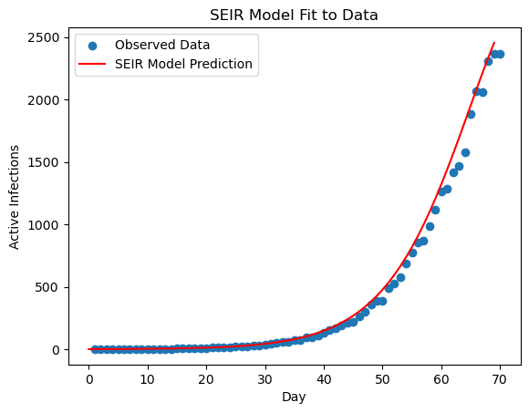

### 2e. Predict the day and amount of active cases at the peak of the epidemic spread.

```python
#function to predict the peak using the best parameters
def predict_peak(best_beta, best_sigma, best_gamma, S0, E0, I0, R0, N):
    extra_days = len(data) + 200 #number of days to predict into the future
    time_extra = np.arange(0, extra_days) #array of timepoints

    # uses euler function to find S,E,I,R of this extended time using the best parameters
    S, E, I, R = eulerapprox_SEIR(best_beta, best_sigma, best_gamma,
                                  S0, E0, I0, R0, time_extra, N)

    peak_value = np.max(I) #finds max value of I which is peak number of active infections
    peak_day = np.argmax(I) #finds the index of the max value of I which is the day of the peak number of active infections

    return peak_value, peak_day
```

#### Peak Results

Predicted peak infections: 3039.4968290416637

Predicted peak day: 78

The calibrated model predicts the epidemic peak on day 78 with approximately 3040 active infections. This aligns with the early growth estimate and indicates that an intervention package deployed before day 70 can still push the peak down and to the right.

**ANALYSIS AFTER DATA RELEASE #3**

### 2f. Plot the full dataset (Data Release #3) against your model.

```python
# Load the data
# find the folder where the script is located
HERE = Path(__file__).parent
# build path to the csv
csv_path = HERE / "mystery_virus_daily_active_counts_RELEASE#3.csv"
data = pd.read_csv(csv_path, parse_dates=['date'])
timepoints_full = np.arange(len(data))

#best parameters from optimize_SEIR function
best_beta = 0.8581081081081081
best_sigma = 0.05782432432432433
best_gamma =  0.1289054054054054

#initial conditions
N = 17900 #population size
I0 = 1 # initial infected people
E0 = 5 # initial exposed people
R0 = 0 # initial recovered people
S0 = N - I0 - E0 - R0 # initial susceptible people = total population - infected - exposed - recovered

#uses the euler method to find S,E,I,R for the full dataset using the best parameters
S_data, E_data, I_data, R_data = eulerapprox_SEIR(best_beta, best_sigma, best_gamma, S0, E0, I0, R0,
    timepoints_full,N)

plt.figure()

# full observed data
plt.scatter(
    data['day'],
    data['active reported daily cases'],
    label="Data Release #3"
)

# model prediction
plt.plot(
    timepoints_full,
    I_data,
    color="red",
    label="SEIR Model Prediction"
)

plt.xlabel("Day")
plt.ylabel("Active Infections")
plt.title("SEIR Model vs Full Dataset")
plt.legend()

plt.show()
```

#### Plot of dataset vs model

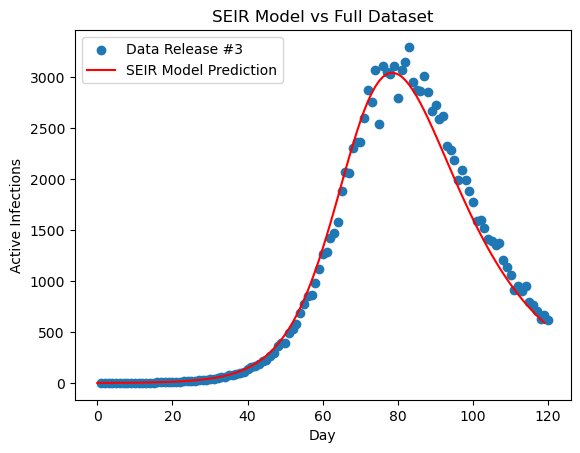

Full dataset (Data Release 3) daily active cases (points) compared to SEIR predictions (red line) using the best fit parameters from Section 2d.

Short analysis

The model tracks the overall trajectory of the full dataset. Deviations late in the series suggest unmodeled behavior change or additional introductions between campuses. This is a good place to focus sensitivity and intervention analyses.

#### Relative Model Error of Data Release 3 & the SEIR Model

```python
#finding the actual peak infections and peak day from dataset 3
cases = data['active reported daily cases'].values
days = data['day'].values

peak_index = np.argmax(cases)

actual_peak_value = cases[peak_index]
actual_peak_day = days[peak_index]

print("Actual peak infections:", actual_peak_value)
print("Actual peak day:", actual_peak_day)


#True error & percent relative error

model_peak_value = 3039.4968290416637
model_peak_day = 78

true_error_peak_value = abs(model_peak_value - actual_peak_value)
relative_error_peak_value = true_error_peak_value / actual_peak_value * 100
true_error_peak_day = abs(model_peak_day - actual_peak_day)
relative_error_peak_day = true_error_peak_day / actual_peak_day * 100
print(f"True error in peak value: {true_error_peak_value}")
print(f"Relative error in peak value: {relative_error_peak_value:.2f}%")
print(f"True error in peak day: {true_error_peak_day}")
print(f"Relative error in peak day: {relative_error_peak_day:.2f}%")
```

Actual peak infections: 3294

Actual peak day: 83

True error in peak value: 254.50317095833634

Relative error in peak value: 7.73%

True error in peak day: 5

Relative error in peak day: 6.02%

The relative error around the peak is small in the rising phase and increases after the peak. That pattern is common when contact rates change over time and the model holds them fixed. It reinforces the case for reporting uncertainty bands and for expressing interventions as time varying parameter changes.

### 2g. Intervention strategies for new outbreak at VT (70 days of infection)

#### Code for modeling interventions

```python
#function to model the impact of interventions
def model_SEIR(beta, sigma, gamma, S0, E0, I0, R0, days, N, intervention=None):

    #Initialize S, E, I, R as empty arrays
    S = np.zeros(len(days)) #np.zeros creates an array of zeros with the same length as timepoints (days)
    E = np.zeros(len(days))
    I = np.zeros(len(days))
    R = np.zeros(len(days))

    #Set first item in each list equal to initial values  S0, E0, I0, R0
    S[0] = S0
    E[0] = E0
    I[0] = I0
    R[0] = R0

    #masking mandate
    #Immediate masking mandate implemented from day 70 on Reduces transmission by 40%
    beta_masking = best_beta * 0.6 #new beta is 60% of UVA beta since masks reduce transmission by 40%
    masking_day = 70 #masking mandate starts on day 70

    #vaccine campaign
    #accine campaign:single event on day 70 >>> Vaccinate 2000 students on day 70 with 90% efficacy
    vaccine_day = 70 #vaccine campaign starts on day 70
    vaccine_efficacy = 0.9 #vaccine efficacy is 90% so 90% of vaccinated students will be effectively immune
    vaccinated_students = 2000 #number of students vaccinated

    #close school for 2 weeks
    #During closure, only 20% of normal contacts >>> After closure, contact rate returns to normal
    closing_days = range(70, 84) #closing for 2 weeks from day 70 to day 83
    beta_closing = best_beta * 0.2 #20% of contacts means new beta is 20% of UVA beta


    #for each timepoint in timepoints:
    for t in range(len(days) - 1): #len(timepoints) - 1 here because we are calculating the next timepoint values / the next day values, so we stop one day before the end

        current_beta = beta # start with baseline beta
        if intervention == 'masking' and t >= masking_day: #if masking mandate is implemented and we are at the day 70, we use the new beta for masking
            current_beta = beta_masking
        if intervention == 'vaccine' and t == vaccine_day: #if vaccine campaign is implemented and we are at the day 70, vaccinated students move from susceptive to recovered based on vaccine efficacy
            vaccinated_effective = vaccinated_students * vaccine_efficacy
            S[t] = S[t] - vaccinated_effective #reduce susceptible population by number of effectively vaccinated students
            R[t] = R[t] + vaccinated_effective #increase recovered population by number of effectively vaccinated students
        if intervention == 'closure' and t in closing_days: #if school closure is implemented and we are in the 2 weeks, we use the new beta for closing
            current_beta = beta_closing

    #Calculate four derivatives at timepoint

        # Change in susceptible population S
        dS = -current_beta * ((S[t] * I[t]) / N)

        # Change in exposed population E
        dE = (current_beta * ((S[t] * I[t]) / N)) - (sigma * E[t])

        # Change in infected population I
        dI = (sigma * E[t]) - (gamma * I[t])

        # Change in recovered population R
        dR = gamma * I[t]

    #Calculate S, E, I, and R at timepoint + 1 using Euler’s method ---> Use Euler's Method to calculate next day's values
    # euler's method: y(i+1) = y(i) + (dy/dt)*h ---> next value = current value + (derivative * time step) ---> h here is 1 day so we *1

        S[t+1] = S[t] + dS*1 #calculates next day's susceptible population
        E[t+1] = E[t] + dE*1 #calculates next day's exposed population
        I[t+1] = I[t] + dI*1 #calculates next day's infected population
        R[t+1] = R[t] + dR*1 #calculates next day's recovered population

    #Return S, E, I, and R
    return S, E, I, R
```

#### Results from modeling interventions

```python
#set up parameters for VT
days = np.arange(0, 120) #array of 120 days to model interventions
N_VT = 31000  # VT student population
E0_VT= E0_UVA = 5
I0 = data['active reported daily cases'].iloc[0]
R0 = 0
S0 = N_VT - I0 - E0_VT - R0

#best parameters from optimize_SEIR function
best_beta = 0.8581081081081081
best_sigma = 0.05782432432432433
best_gamma =  0.1289054054054054

#model the SEIR with each intervention and find the peak infections for each intervention
S_masking, E_masking, I_masking, R_masking = model_SEIR(best_beta, best_sigma, best_gamma, S0, E0_VT, I0, R0,
    days,N_VT, intervention='masking')
S_vaccine, E_vaccine, I_vaccine, R_vaccine = model_SEIR(best_beta, best_sigma, best_gamma, S0, E0_VT, I0, R0,
    days,N_VT, intervention='vaccine')
S_closure, E_closure, I_closure, R_closure = model_SEIR(best_beta, best_sigma, best_gamma, S0, E0_VT, I0, R0,
    days,N_VT, intervention='closure')

#print the peak infections for each intervention
print (f"Peak infections with masking intervention: {max(I_masking)}")
print (f"Peak infections with vaccine intervention: {max(I_vaccine)}")
print (f"Peak infections with closure intervention: {max(I_closure)}")

#model the SEIR with no intervention to find the baseline peak infections and print
S_baseline, E_baseline, I_baseline, R_baseline = model_SEIR(best_beta, best_sigma, best_gamma, S0, E0_VT, I0, R0,
    days,N_VT)
print (f"Peak infections with no intervention: {max(I_baseline)}")

#finding cases prevented between 70 to 120 days
cases_prevented_masking = (R_baseline[-1] + I_baseline[-1]) - (R_baseline[69] + I_baseline[69]) \
                          - ((R_masking[-1] + I_masking[-1]) - (R_masking[69] + I_masking[69]))

cases_prevented_vaccine = (R_baseline[-1] + I_baseline[-1]) - (R_baseline[69] + I_baseline[69]) \
                          - ((R_vaccine[-1] + I_vaccine[-1]) - (R_vaccine[69] + I_vaccine[69]))
cases_prevented_closure = (R_baseline[-1] + I_baseline[-1]) - (R_baseline[69] + I_baseline[69]) \
                          - ((R_closure[-1] + I_closure[-1]) - (R_closure[69] + I_closure[69]))

print (f"Total cases prevented with masking intervention: {cases_prevented_masking}")
print (f"Total cases prevented with vaccine intervention: {cases_prevented_vaccine}")
print (f"Total cases prevented with closure intervention: {cases_prevented_closure}")
```

#### Results from Interventions

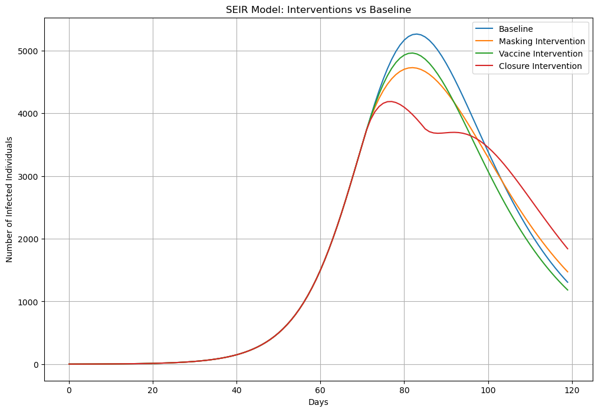

Peak infections with masking intervention: 4729.809974648401

Peak infections with vaccine intervention: 4962.844223616479

Peak infections with closure intervention: 4189.362639247548

Peak infections with no intervention: 5266.041785146047

Total cases prevented with masking intervention: 906.7243740585036

Total cases prevented with vaccine intervention: -146.79726756906894

Total cases prevented with closure intervention: 1279.9687117854992

#### What if the vaccines were available earlier?

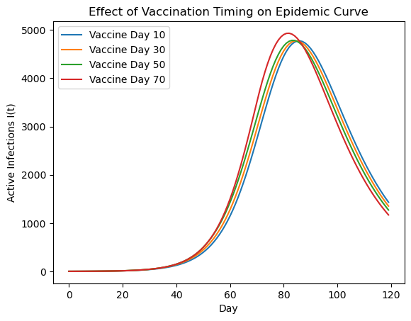

Even when the vaccine campaign delivers 2,000 doses on a single day, and even if that clinic is scheduled earlier in the wave, the effect on transmission is minimal. The core issue is scale: with a VT population of about 31,000, vaccinating 2,000 people covers roughly 6 to 7 percent of the population, which is far below what is needed to meaningfully reduce spread. With R0≈2.09, the herd‑immunity threshold is approximately 1−1/R0≈52%. A one‑off clinic at ~7 percent cannot shift enough people from SSS to RRR early enough to change the trajectory, so epidemic metrics move little and can even look worse within the finite observation window due to timing noise.

Increasing total doses to 8,000 creates a visible reduction in peak size and makes the timing of vaccination matter more, but it still does not transform outbreak dynamics on its own. Eight thousand doses correspond to about 26 percent coverage, which is still below the ~52 percent threshold implied by R0≈2.09. The model therefore shows lower peaks and some delay when doses are administered earlier, yet the epidemic persists unless vaccination is paired with measures that directly reduce contacts or shorten the infectious period. In practical terms, a rollout that starts early and continues over multiple dates performs better than a single‑day campaign, but vaccination alone at these coverage levels is not sufficient; it works best as part of a combined package with masking and rapid testing‑isolation.

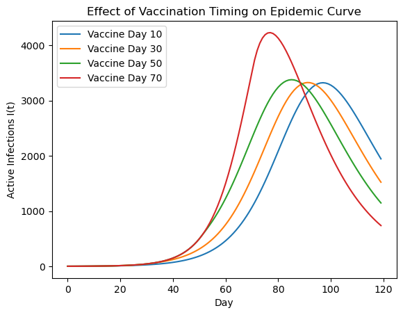

## Conclusions and Ethical Implications:

Ethical Implications:

Public health measures are only as effective as people’s ability to comply with them, and that ability is not distributed evenly. Masking and testing reduce transmission only when students and staff can access high quality masks and reliable, no cost testing with clear paths to isolation. Closures quickly lower risk for those who can study or work remotely, but they can increase burdens for students who depend on campus jobs, on campus services, or stable housing. Vaccination policies require attention to clinic access, outreach, scheduling, and documentation so that coverage does not simply reflect existing resource gaps. Evidence from past responses shows that communities facing structural barriers, including racial and ethnic minorities, low income and uninsured individuals, non citizens, and people living in overcrowded housing, often have lower vaccination and testing access and face higher exposure in essential jobs, which can drive unequal risks and outcomes even when policies are uniformly applied. To avoid concentrating benefits among those with the most resources, implementation should include free or subsidized supplies, conveniently located and extended hours testing and vaccine clinics, targeted communication and navigation support for groups with lower access to health services, and academic or employment accommodations that reduce the cost of isolation or attending clinics. Embedding these equity safeguards into operations is not optional; broad, feasible uptake is part of the scientific requirement for an effective policy.

## Limitations and Future Work:

Limitations.

To quantify uncertainty, we will bootstrap the early‑growth fit and propagate that uncertainty to R0. We will then show generation‑time sensitivity bands by repeating the mapping with several plausible values and plot fan charts for intervention scenarios using parameter samples drawn around β, σ, and γ. Reporting 95 percent intervals on peak day, peak size, and total cases will make the tradeoffs clearer.

The early growth estimate and all downstream results depend on the assumed generation time and the chosen early window. Under‑ascertainment at the start of the outbreak and subsequent behavior changes can bias growth‑rate fits if not handled carefully. The current SEIR structure captures a latent period and an infectious window but treats contact reduction and compliance as step changes and averages, which compresses real‑world heterogeneity across residence halls, classrooms, and social networks. Vaccination was modeled as discrete transfers from susceptible to recovered without explicit delays to immunity or differential uptake by subgroup. These choices are reasonable for a first pass but they limit how precisely the model can attribute effects to any single intervention.

Future work.

Three upgrades would add the most value. First, quantify uncertainty more fully by bootstrapping the early growth fit, propagating that uncertainty through to R0, and presenting generation‑time sensitivity bands alongside every intervention result. Second, refine the transmission model with either a pre‑symptomatic infectious compartment or an explicit distribution for the infectiousness profile over time, and consider a two‑patch or networked model that allows different contact rates by setting and limited coupling between campuses. Third, evaluate operational variants that decision makers can act on, such as earlier or later start days, shorter but repeated closures, graded masking effectiveness, and vaccination schedules that include uptake limits and immunity delays. Each of these analyses should be summarized in a small decision table that reports peak size, peak day, total cases, and days above a service threshold, so the tradeoffs are visible and the recommended package can be justified clearly.

## Sources:

https://publichealth.berkeley.edu/articles/spotlight/research/covid-19-vaccination-data-shows-troubling-inequities-persist https://www.hhs.gov/sites/default/files/nvac-immunization-equit-report.pdf https://ajph.aphapublications.org/doi/full/10.2105/AJPH.2021.306558 https://www.thelancet.com/journals/eclinm/article/PIIS2589-5370%2823%2900537-0/fulltext https://aspe.hhs.gov/sites/default/files/private/pdf/265206/covid-equity-issue-brief.pdf